# hw11

2022-05-12

```r
# 라이브러리 포함
library(olsrr)
library(dplyr)
library(DAAG)
```

```r
library(ggplot2)
library(mlbench)
library(tidyverse)
library(patchwork)
```

#2데이터 선택및 확인

*데이터 제목: Possum Regression(주머니 쥐 회귀)

*출처:https://www.kaggle.com/datasets/abrambeyer/openintro-possum?resource=download

*설명: 13가지의 예측변수를 바탕으로 주머니 쥐의 성별을 예측하는 데이터셋

*수집 목적:

*예측변수 >site(뎃에 잡힌 주머니쥐의 장소 번호)외 12개

*목표 변수 >sex(성별)

```r
# 데이터 포함 및 데이터 확인
data <- read.csv('possum.csv')

summary(data)
```

```
##       case             site           Pop                sex
##  Min.   :  1.00   Min.   :1.000   Length:104         Length:104
##  1st Qu.: 26.75   1st Qu.:1.000   Class :character   Class :character
##  Median : 52.50   Median :3.000   Mode  :character   Mode  :character
##  Mean   : 52.50   Mean   :3.625
##  3rd Qu.: 78.25   3rd Qu.:6.000
##  Max.   :104.00   Max.   :7.000
##
##       age           hdlngth           skullw         totlngth
##  Min.   :1.000   Min.   : 82.50   Min.   :50.00   Min.   :75.00
##  1st Qu.:2.250   1st Qu.: 90.67   1st Qu.:54.98   1st Qu.:84.00
##  Median :3.000   Median : 92.80   Median :56.35   Median :88.00
##  Mean   :3.833   Mean   : 92.60   Mean   :56.88   Mean   :87.09
##  3rd Qu.:5.000   3rd Qu.: 94.72   3rd Qu.:58.10   3rd Qu.:90.00
##  Max.   :9.000   Max.   :103.10   Max.   :68.60   Max.   :96.50
##  NA's   :2
##      taill          footlgth        earconch          eye            chest
##  Min.   :32.00   Min.   :60.30   Min.   :40.30   Min.   :12.80   Min.   :22.0
##  1st Qu.:35.88   1st Qu.:64.60   1st Qu.:44.80   1st Qu.:14.40   1st Qu.:25.5
##  Median :37.00   Median :68.00   Median :46.80   Median :14.90   Median :27.0
##  Mean   :37.01   Mean   :68.46   Mean   :48.13   Mean   :15.05   Mean   :27.0
##  3rd Qu.:38.00   3rd Qu.:72.50   3rd Qu.:52.00   3rd Qu.:15.72   3rd Qu.:28.0
##  Max.   :43.00   Max.   :77.90   Max.   :56.20   Max.   :17.80   Max.   :32.0
##                  NA's   :1
##      belly
##  Min.   :25.00
##  1st Qu.:31.00
##  Median :32.50
##  Mean   :32.59
##  3rd Qu.:34.12
##  Max.   :40.00
##
```

```r
head(data)
```

```
##   case site Pop sex age hdlngth skullw totlngth taill footlgth earconch  eye
## 1    1    1 Vic   m   8    94.1   60.4     89.0  36.0     74.5     54.5 15.2
## 2    2    1 Vic   f   6    92.5   57.6     91.5  36.5     72.5     51.2 16.0
## 3    3    1 Vic   f   6    94.0   60.0     95.5  39.0     75.4     51.9 15.5
## 4    4    1 Vic   f   6    93.2   57.1     92.0  38.0     76.1     52.2 15.2
## 5    5    1 Vic   f   2    91.5   56.3     85.5  36.0     71.0     53.2 15.1
## 6    6    1 Vic   f   1    93.1   54.8     90.5  35.5     73.2     53.6 14.2
##   chest belly
## 1  28.0    36
## 2  28.5    33
## 3  30.0    34
## 4  28.0    34
## 5  28.5    33
## 6  30.0    32
```

데이터 전처리 1~3열 제거 (case: 순서, site : 덧에 잡힌 장소 번호 , pop: 인구..? 장소…?)

명목형 변수인 sex의 m, f는 각각 1,2 로 변경

```r
d<-data[,-c(1,2,3)]
head(d)
```

```
##   sex age hdlngth skullw totlngth taill footlgth earconch  eye chest belly
## 1   m   8    94.1   60.4     89.0  36.0     74.5     54.5 15.2  28.0    36
## 2   f   6    92.5   57.6     91.5  36.5     72.5     51.2 16.0  28.5    33
## 3   f   6    94.0   60.0     95.5  39.0     75.4     51.9 15.5  30.0    34
## 4   f   6    93.2   57.1     92.0  38.0     76.1     52.2 15.2  28.0    34
## 5   f   2    91.5   56.3     85.5  36.0     71.0     53.2 15.1  28.5    33
## 6   f   1    93.1   54.8     90.5  35.5     73.2     53.6 14.2  30.0    32
```

```r
df <- na.omit(d)  # 모든 변수에 결측치 없는 데이터 추출
df
```

```
##     sex age hdlngth skullw totlngth taill footlgth earconch  eye chest belly
## 1     m   8    94.1   60.4     89.0  36.0     74.5     54.5 15.2  28.0  36.0
## 2     f   6    92.5   57.6     91.5  36.5     72.5     51.2 16.0  28.5  33.0
## 3     f   6    94.0   60.0     95.5  39.0     75.4     51.9 15.5  30.0  34.0
## 4     f   6    93.2   57.1     92.0  38.0     76.1     52.2 15.2  28.0  34.0
## 5     f   2    91.5   56.3     85.5  36.0     71.0     53.2 15.1  28.5  33.0
## 6     f   1    93.1   54.8     90.5  35.5     73.2     53.6 14.2  30.0  32.0
## 7     m   2    95.3   58.2     89.5  36.0     71.5     52.0 14.2  30.0  34.5
## 8     f   6    94.8   57.6     91.0  37.0     72.7     53.9 14.5  29.0  34.0
## 9     f   9    93.4   56.3     91.5  37.0     72.4     52.9 15.5  28.0  33.0
## 10    f   6    91.8   58.0     89.5  37.5     70.9     53.4 14.4  27.5  32.0
## 11    f   9    93.3   57.2     89.5  39.0     77.2     51.3 14.9  31.0  34.0
## 12    f   5    94.9   55.6     92.0  35.5     71.7     51.0 15.3  28.0  33.0
## 13    m   5    95.1   59.9     89.5  36.0     71.0     49.8 15.8  27.0  32.0
## 14    m   3    95.4   57.6     91.5  36.0     74.3     53.7 15.1  28.0  31.5
```

[output cut: 87 more lines]

```r
table(is.na(df))
```

```
##
## FALSE
##  1111
```

```r
summary(df)
```

```
##      sex                 age           hdlngth           skullw
##  Length:101         Min.   :1.000   Min.   : 82.50   Min.   :50.00
##  Class :character   1st Qu.:2.000   1st Qu.: 90.70   1st Qu.:55.00
##  Mode  :character   Median :3.000   Median : 92.90   Median :56.40
##                     Mean   :3.822   Mean   : 92.73   Mean   :56.96
##                     3rd Qu.:5.000   3rd Qu.: 94.80   3rd Qu.:58.10
##                     Max.   :9.000   Max.   :103.10   Max.   :68.60
##     totlngth         taill          footlgth       earconch          eye
##  Min.   :75.00   Min.   :32.00   Min.   :60.3   Min.   :41.30   Min.   :12.80
##  1st Qu.:84.50   1st Qu.:36.00   1st Qu.:64.5   1st Qu.:44.80   1st Qu.:14.40
##  Median :88.00   Median :37.00   Median :67.9   Median :46.80   Median :14.90
##  Mean   :87.27   Mean   :37.05   Mean   :68.4   Mean   :48.13   Mean   :15.05
##  3rd Qu.:90.00   3rd Qu.:38.00   3rd Qu.:72.5   3rd Qu.:52.00   3rd Qu.:15.70
##  Max.   :96.50   Max.   :43.00   Max.   :77.9   Max.   :56.20   Max.   :17.80
##      chest           belly
##  Min.   :22.00   Min.   :25.00
##  1st Qu.:25.50   1st Qu.:31.00
##  Median :27.00   Median :32.50
##  Mean   :27.06   Mean   :32.64
##  3rd Qu.:28.00   3rd Qu.:34.00
##  Max.   :32.00   Max.   :40.00
```

```r
head(df)
```

```
##   sex age hdlngth skullw totlngth taill footlgth earconch  eye chest belly
## 1   m   8    94.1   60.4     89.0  36.0     74.5     54.5 15.2  28.0    36
## 2   f   6    92.5   57.6     91.5  36.5     72.5     51.2 16.0  28.5    33
## 3   f   6    94.0   60.0     95.5  39.0     75.4     51.9 15.5  30.0    34
## 4   f   6    93.2   57.1     92.0  38.0     76.1     52.2 15.2  28.0    34
## 5   f   2    91.5   56.3     85.5  36.0     71.0     53.2 15.1  28.5    33
## 6   f   1    93.1   54.8     90.5  35.5     73.2     53.6 14.2  30.0    32
```

```r
df$sex[df$sex == 'm'] <- as.numeric(1)
df$sex[df$sex == 'f'] <- as.numeric(2)
head(df)
```

```
##   sex age hdlngth skullw totlngth taill footlgth earconch  eye chest belly
## 1   1   8    94.1   60.4     89.0  36.0     74.5     54.5 15.2  28.0    36
## 2   2   6    92.5   57.6     91.5  36.5     72.5     51.2 16.0  28.5    33
## 3   2   6    94.0   60.0     95.5  39.0     75.4     51.9 15.5  30.0    34
## 4   2   6    93.2   57.1     92.0  38.0     76.1     52.2 15.2  28.0    34
## 5   2   2    91.5   56.3     85.5  36.0     71.0     53.2 15.1  28.5    33
## 6   2   1    93.1   54.8     90.5  35.5     73.2     53.6 14.2  30.0    32
```

```r
str(df)
```

```
## 'data.frame':    101 obs. of  11 variables:
##  $ sex     : chr  "1" "2" "2" "2" ...
##  $ age     : int  8 6 6 6 2 1 2 6 9 6 ...
##  $ hdlngth : num  94.1 92.5 94 93.2 91.5 93.1 95.3 94.8 93.4 91.8 ...
##  $ skullw  : num  60.4 57.6 60 57.1 56.3 54.8 58.2 57.6 56.3 58 ...
##  $ totlngth: num  89 91.5 95.5 92 85.5 90.5 89.5 91 91.5 89.5 ...
##  $ taill   : num  36 36.5 39 38 36 35.5 36 37 37 37.5 ...
##  $ footlgth: num  74.5 72.5 75.4 76.1 71 73.2 71.5 72.7 72.4 70.9 ...
##  $ earconch: num  54.5 51.2 51.9 52.2 53.2 53.6 52 53.9 52.9 53.4 ...
##  $ eye     : num  15.2 16 15.5 15.2 15.1 14.2 14.2 14.5 15.5 14.4 ...
##  $ chest   : num  28 28.5 30 28 28.5 30 30 29 28 27.5 ...
##  $ belly   : num  36 33 34 34 33 32 34.5 34 33 32 ...
##  - attr(*, "na.action")= 'omit' Named int [1:3] 41 44 46
##   ..- attr(*, "names")= chr [1:3] "41" "44" "46"
```

데이터 분포 확인

```r
p1<-ggplot(data=df) + geom_density(mapping=aes(x=age, colour = sex))
p2<-ggplot(data=df) + geom_density(mapping=aes(x=hdlngth, colour = sex))
p3<-ggplot(data=df) + geom_density(mapping=aes(x=skullw, colour = sex))
p4<-ggplot(data=df) + geom_density(mapping=aes(x=totlngth, colour = sex))
p5<-ggplot(data=df) + geom_density(mapping=aes(x=taill, colour = sex))
p6<-ggplot(data=df) + geom_density(mapping=aes(x=footlgth, colour = sex))
p7<-ggplot(data=df) + geom_density(mapping=aes(x=earconch, colour = sex))
p8<-ggplot(data=df) + geom_density(mapping=aes(x=eye, colour = sex))
p9<-ggplot(data=df) + geom_density(mapping=aes(x=chest, colour = sex))
p10<-ggplot(data=df) + geom_density(mapping=aes(x=belly, colour = sex))
```

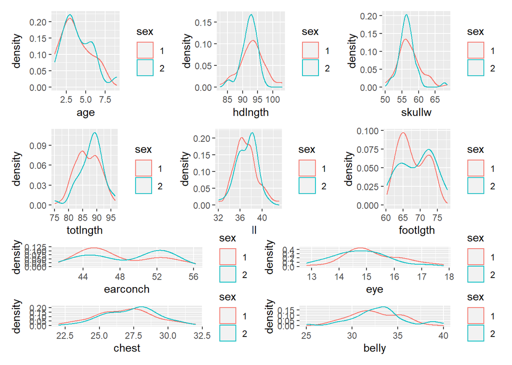

```r
(p1+p2+p3)/(p4+p5+p6)/(p7+p8+p9+p10)
```

#3예측 모델 생성

Residuals:잔차를 의미합니다. 회귀식에 의해 추정된 값과 실제값(입력값)의 차이 입니다. 최솟값/1사분위수/ 중앙값/ 3사분위수/ 최대값

```
 Min       1Q   Median       3Q      Max
```

-0.68340 -0.36988 -0.09692 0.34943 1.07571

Coefficients:추정된 회귀식의 계수를 의미 합니다. 추정된계수 / 표준오차 / t 값(점수) / p-value

```
         Estimate Std. Error t value  Pr(>|t|)
```

(Intercept) 3.557151 1.899233 1.873 0.0659 . age 0.043605 0.035435 1.231 0.2232  
hdlngth -0.052560 0.026745 -1.965 0.0539 . eye -0.128666 0.056136 -2.292 0.0254 *

(Intercept)=> 절편

F-statistic: 2.067 on 10 and 61 DF, p-value: 0.04125 => 모형 전체의 유의성 판단 || p-value: 0.04125=> 유의

Residual standard error: 0.4629 on 61 degrees of freedom => 잔차의 표준오차 : 0.4629 || 자유도는 61(관측값에서 -1?)

t값: 각 독립변수의 유의성 판단을 위한 통계량

```r
set.seed(1000)
idx<- caret::createDataPartition(df$sex, p=0.7)
df_train<-df[idx$Resample1,] # 트레인
df_test<-df[-idx$Resample1,] # 테스트
df_train
```

```
##     sex age hdlngth skullw totlngth taill footlgth earconch  eye chest belly
## 2     2   6    92.5   57.6     91.5  36.5     72.5     51.2 16.0  28.5  33.0
## 4     2   6    93.2   57.1     92.0  38.0     76.1     52.2 15.2  28.0  34.0
## 8     2   6    94.8   57.6     91.0  37.0     72.7     53.9 14.5  29.0  34.0
## 11    2   9    93.3   57.2     89.5  39.0     77.2     51.3 14.9  31.0  34.0
## 12    2   5    94.9   55.6     92.0  35.5     71.7     51.0 15.3  28.0  33.0
## 13    1   5    95.1   59.9     89.5  36.0     71.0     49.8 15.8  27.0  32.0
## 14    1   3    95.4   57.6     91.5  36.0     74.3     53.7 15.1  28.0  31.5
## 16    1   4    91.6   56.0     86.0  34.5     73.0     51.4 14.4  28.0  32.0
## 17    2   1    94.7   67.7     89.5  36.5     73.2     53.2 14.7  29.0  31.0
## 18    1   2    93.5   55.7     90.0  36.0     73.7     55.4 15.3  28.0  32.0
## 19    2   5    94.4   55.4     90.5  35.0     73.4     53.9 15.2  28.0  32.0
## 21    2   3    95.9   58.1     96.5  39.5     77.9     52.9 14.2  30.0  40.0
## 22    1   3    96.3   58.5     91.0  39.5     73.5     52.1 16.2  28.0  36.0
## 23    2   4    92.5   56.1     89.0  36.0     72.8     53.3 15.4  28.0  35.0
```

[output cut: 58 more lines]

```r
lmMod <- lm(sex ~ age + hdlngth + skullw + totlngth+taill+footlgth+earconch+eye+chest+belly, data=df_train)  # build the model
distPred <- predict(lmMod, df_test)
distPred
```

```
##         1         3         5         6         7         9        10        15
## 1.8665541 1.8103810 1.4361548 1.6143175 1.5372564 1.8413914 1.7809551 1.5237494
##        20        26        33        34        36        45        47        49
## 1.5853773 1.8614721 1.6055467 1.4561327 1.9235679 1.4334349 1.5798190 1.1477745
##        51        60        62        70        71        80        84        86
## 1.0862588 1.3197462 1.3158674 1.8381348 1.5412902 1.3746682 0.9795228 1.5827372
##        87        88        89       101       103
## 1.3682471 1.3062909 1.0819393 1.4333902 1.0850586
```

```r
summary (lmMod)
```

```
##
## Call:
## lm(formula = sex ~ age + hdlngth + skullw + totlngth + taill +
##     footlgth + earconch + eye + chest + belly, data = df_train)
##
## Residuals:
##      Min       1Q   Median       3Q      Max
## -0.68340 -0.36988 -0.09692  0.34943  1.07571
##
## Coefficients:
##              Estimate Std. Error t value Pr(>|t|)
## (Intercept)  3.557151   1.899233   1.873   0.0659 .
## age          0.043605   0.035435   1.231   0.2232
## hdlngth     -0.052560   0.026745  -1.965   0.0539 .
## skullw      -0.005841   0.025242  -0.231   0.8178
## totlngth     0.041293   0.024743   1.669   0.1003
## taill       -0.025007   0.042030  -0.595   0.5541
## footlgth     0.014677   0.024808   0.592   0.5563
## earconch     0.007394   0.026215   0.282   0.7789
## eye         -0.128666   0.056136  -2.292   0.0254 *
## chest       -0.020501   0.047454  -0.432   0.6673
## belly        0.042161   0.029095   1.449   0.1524
## ---
## Signif. codes:  0 '***' 0.001 '**' 0.01 '*' 0.05 '.' 0.1 ' ' 1
##
## Residual standard error: 0.4629 on 61 degrees of freedom
## Multiple R-squared:  0.2531, Adjusted R-squared:  0.1307
## F-statistic: 2.067 on 10 and 61 DF,  p-value: 0.04125
```

양의 회귀계수와 음의 회귀계수가 혼재 되어 있음 p-value를 보았을때 회귀계수의 부호가 유의성을 설명하지는 않음

ㅡㅡㅡㅡㅡㅡㅡㅡㅡㅡㅡㅡㅡㅡㅡㅡㅡㅡㅡㅡㅡㅡㅡㅡㅡㅡㅡㅡㅡㅡㅡㅡㅡㅡㅡㅡ

학습한 모델의 예측값와 테스트 데이터비교 => 정확성

```r
actuals_preds <- data.frame(cbind(actuals=as.numeric(df_test$sex), predicteds=distPred))  # make actuals_predicteds dataframe.
actuals_preds
```

```
##     actuals predicteds
## 1         1  1.8665541
## 3         2  1.8103810
## 5         2  1.4361548
## 6         2  1.6143175
## 7         1  1.5372564
## 9         2  1.8413914
## 10        2  1.7809551
## 15        1  1.5237494
## 20        2  1.5853773
## 26        1  1.8614721
## 33        1  1.6055467
## 34        1  1.4561327
## 36        1  1.9235679
## 45        1  1.4334349
## 47        1  1.5798190
## 49        1  1.1477745
## 51        2  1.0862588
## 60        2  1.3197462
## 62        2  1.3158674
## 70        2  1.8381348
## 71        1  1.5412902
## 80        1  1.3746682
## 84        1  0.9795228
## 86        2  1.5827372
## 87        1  1.3682471
## 88        2  1.3062909
## 89        1  1.0819393
## 101       1  1.4333902
## 103       1  1.0850586
```

```r
correlation_accuracy <- cor(actuals_preds)
correlation_accuracy
```

```
##              actuals predicteds
## actuals    1.0000000  0.1596765
## predicteds 0.1596765  1.0000000
```

```r
head(actuals_preds)
```

```
##   actuals predicteds
## 1       1   1.866554
## 3       2   1.810381
## 5       2   1.436155
## 6       2   1.614317
## 7       1   1.537256
## 9       2   1.841391
```

**최소최대 정확도와, 절대 백분율 편차 를 이용한 정확성**

age를 수치화 해서 그런지 mape값이 너무 낮음

```r
min_max_accuracy <- mean(apply(actuals_preds, 1, min) / apply(actuals_preds, 1, max))
min_max_accuracy #0.74 => 실제값과 예측값이 얼마나 근접한가
```

```
## [1] 0.7344838
```

```r
mape <- mean(abs((actuals_preds$predicteds - actuals_preds$actuals))/actuals_preds$actuals)
mape # 절대 백분율 편차 0.35 => 오차와 실제의 비율
```

```
## [1] 0.3648818
```

#4예측 모델의 성능 rmse 오차 테스트(함수 rmse, cv rmse)

:cross vallidation 한쪽이 근사하게 낮으나 거의 비슷 그러나 rmse너무 높음

```r
rmse<-function(y1,y2){
  sqrt(mean((y1-y2)^2))
}

rmse_test_lm<-rmse(distPred,as.numeric(df_test$sex))
rmse_test_lm
```

```
## [1] 0.5250852
```

```r
cvResults <- suppressWarnings(
  CVlm(data = df,
       form.lm=as.numeric(sex) ~ age + hdlngth + skullw + totlngth+taill+footlgth+earconch+eye+chest+belly,
       m=10,
       dots=FALSE,
       seed=29,
       legend.pos="topleft",
       printit=FALSE,
       main="Small symbols are predicted values while bigger ones are actuals."));
```

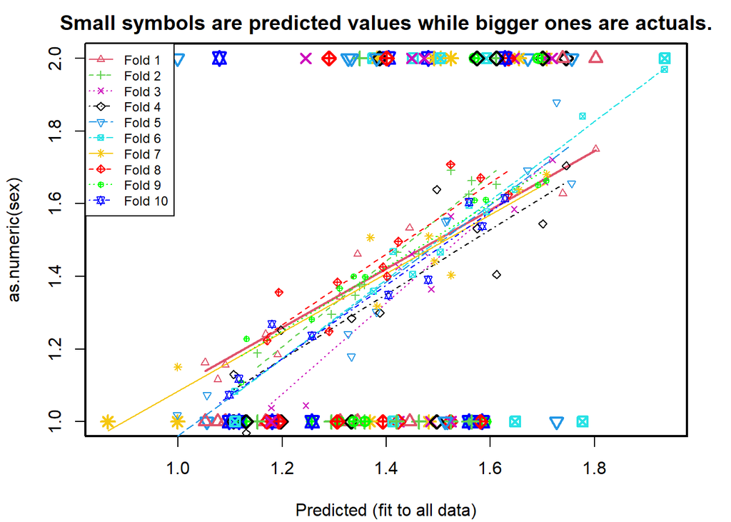

```r
# performs the CV

cv_ms<-attr(cvResults, 'ms')
cv_rms<-sqrt(cv_ms)
cv_rms
```

```
## [1] 0.4914611
```

#5 설명 모델 생성과 설명모델 로서의 성능

A: 설명(종속변수와 독립변수간의 유의성 )하는것이 목적임

B:

F-statistic: 2.174 on 10 and 90 DF, p-value: 0.02645

=> 모형 전체의 유의성 판단 || p-value: 0.02645=> 유의

C:

t-value값 기준 p-value 작은 순서

=>hdlngth>totlngth>eye>chest>belly>skullw>age>taill>footlgth>earconch

```r
model <- lm(as.numeric(sex) ~ age + hdlngth + skullw + totlngth+taill+footlgth+earconch+eye+chest+belly, data = df)
model
```

```
##
## Call:
## lm(formula = as.numeric(sex) ~ age + hdlngth + skullw + totlngth +
##     taill + footlgth + earconch + eye + chest + belly, data = df)
##
## Coefficients:
## (Intercept)          age      hdlngth       skullw     totlngth        taill
##    3.951929     0.020123    -0.058726    -0.018179     0.049529    -0.025153
##    footlgth     earconch          eye        chest        belly
##    0.004564    -0.003706    -0.084972     0.036906     0.019116
```

```r
summary(model)
```

```
##
## Call:
## lm(formula = as.numeric(sex) ~ age + hdlngth + skullw + totlngth +
##     taill + footlgth + earconch + eye + chest + belly, data = df)
##
## Residuals:
##     Min      1Q  Median      3Q     Max
## -0.7774 -0.3691 -0.1090  0.3881  1.0015
##
## Coefficients:
##              Estimate Std. Error t value Pr(>|t|)
## (Intercept)  3.951929   1.731041   2.283   0.0248 *
## age          0.020123   0.027255   0.738   0.4622
## hdlngth     -0.058726   0.023357  -2.514   0.0137 *
## skullw      -0.018179   0.023068  -0.788   0.4327
## totlngth     0.049529   0.021536   2.300   0.0238 *
## taill       -0.025153   0.037348  -0.673   0.5024
## footlgth     0.004564   0.021824   0.209   0.8348
## earconch    -0.003706   0.022333  -0.166   0.8686
## eye         -0.084972   0.049719  -1.709   0.0909 .
## chest        0.036906   0.037069   0.996   0.3221
## belly        0.019116   0.023562   0.811   0.4193
## ---
## Signif. codes:  0 '***' 0.001 '**' 0.01 '*' 0.05 '.' 0.1 ' ' 1
##
## Residual standard error: 0.4686 on 90 degrees of freedom
## Multiple R-squared:  0.1945, Adjusted R-squared:  0.105
## F-statistic: 2.174 on 10 and 90 DF,  p-value: 0.02645
```

D: (선택1)stepwise-selection 진행

모델의 잔차와 측정 값

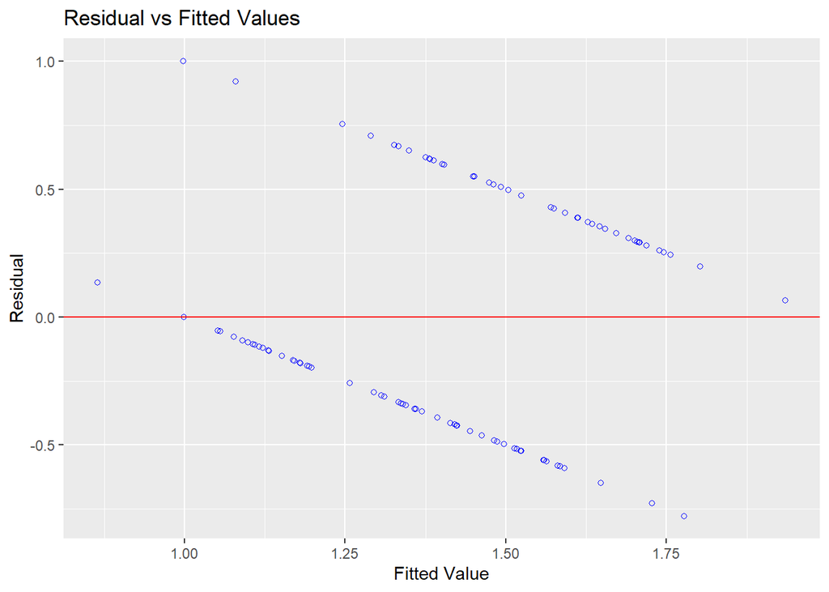

```r
ols_plot_resid_fit(model)
```

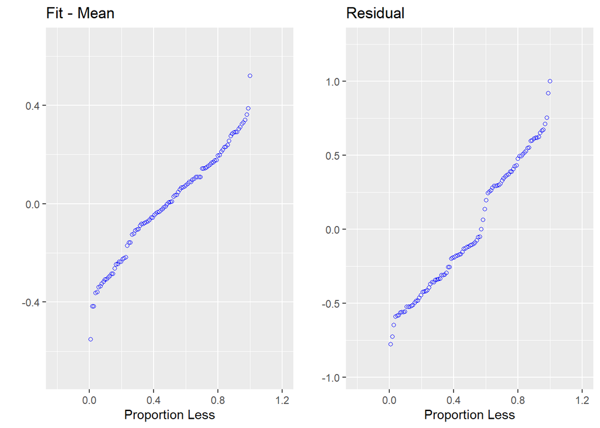

```r
ols_plot_resid_fit_spread(model)
```

전방 선택 방식

eye>totlngth>hdlngth>chest 전방 선택시 순서로 중요한 변수임

```r
k <- ols_step_forward_p(model) #
k
```

```
##
##                            Selection Summary
## ------------------------------------------------------------------------
##         Variable                  Adj.
## Step    Entered     R-Square    R-Square     C(p)       AIC        RMSE
## ------------------------------------------------------------------------
##    1    eye           0.0450      0.0353    9.7112    145.0591    0.4865
##    2    totlngth      0.0897      0.0711    6.7170    142.2180    0.4774
##    3    hdlngth       0.1465      0.1201    2.3697    137.7103    0.4646
##    4    chest         0.1698      0.1352    1.7679    136.9166    0.4606
## ------------------------------------------------------------------------
```

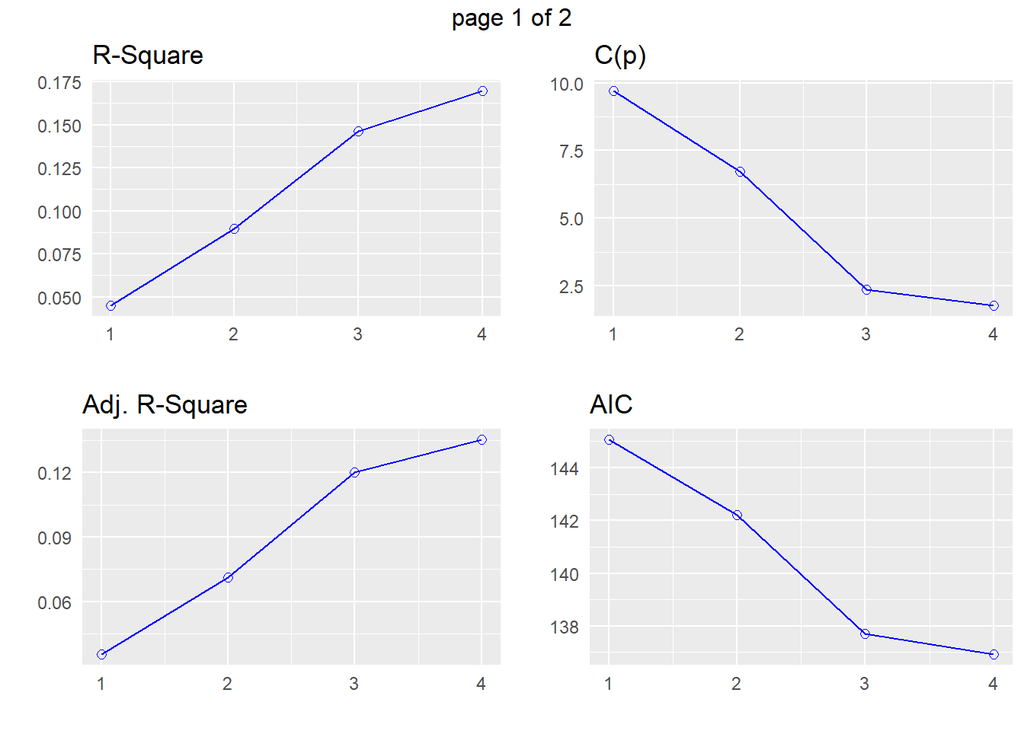

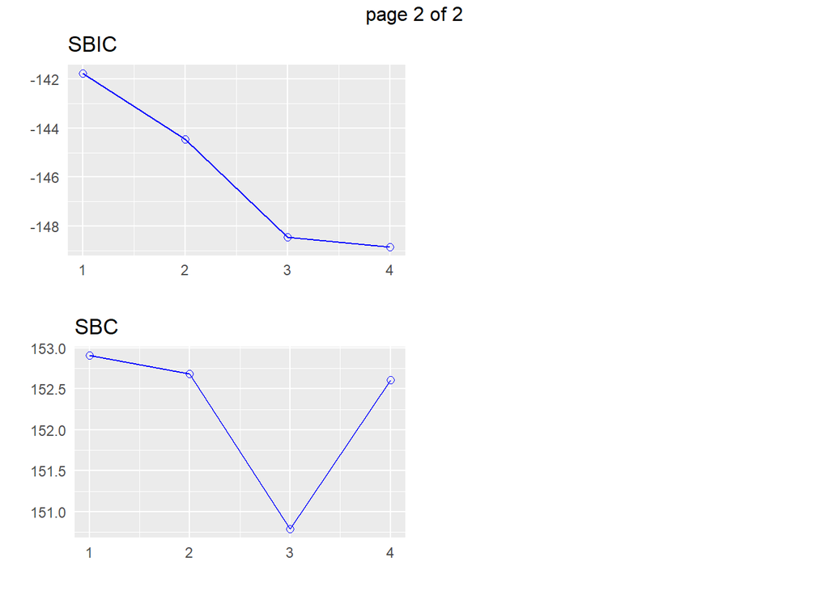

```r
plot(k)
```

후방 선택 방식

후방제거 시 earconch>footlgth>age>skullw>shest>taill 순서로 빠져야 함

```r
k <- ols_step_backward_aic(model) # for backward, ols_step_forward_aic()
k
```

```
##
##
##                    Backward Elimination Summary
## -----------------------------------------------------------------
## Variable        AIC       RSS      Sum Sq     R-Sq      Adj. R-Sq
## -----------------------------------------------------------------
## Full Model    145.857    19.762     4.773    0.19454      0.10504
## earconch      143.888    19.768     4.767    0.19429      0.11460
## footlgth      141.907    19.771     4.763    0.19414      0.12407
## age           140.480    19.884     4.651    0.18955      0.12855
## skullw        139.140    20.014     4.520    0.18424      0.13217
## chest         138.055    20.197     4.338    0.17681      0.13349
## taill         137.495    20.487     4.048    0.16499      0.13020
## -----------------------------------------------------------------
```

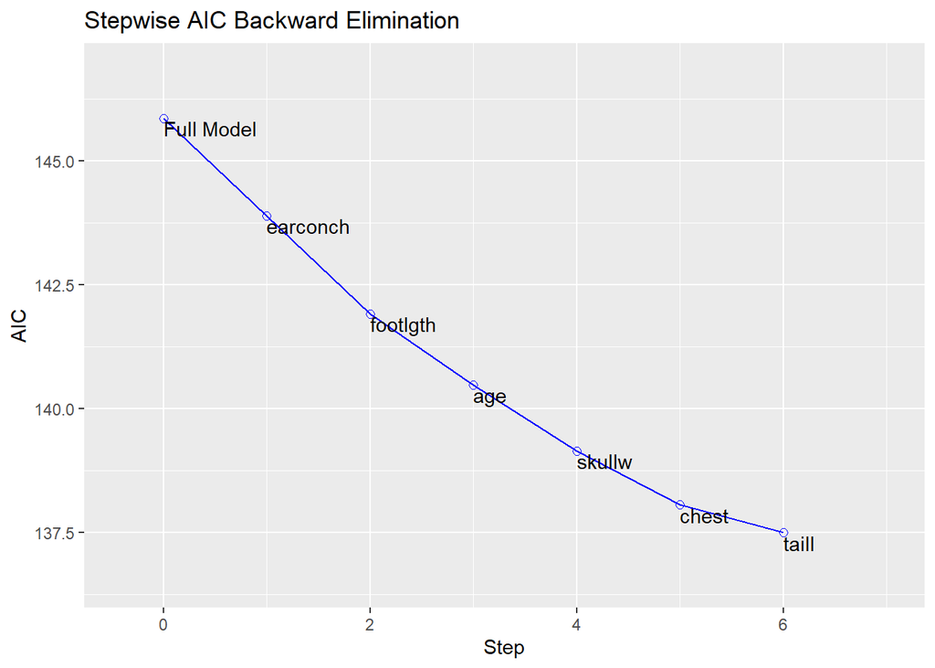

```r
plot(k)
```

두 방식을 모두 이용한 회귀

eye(addition)>totlngth(addition)>hdlngth(addition) 순서

```r
k <- ols_step_both_p(model) # for aic, ols_step_both_p()
k
```

```
##
##                              Stepwise Selection Summary
## ------------------------------------------------------------------------------------
##                      Added/                   Adj.
## Step    Variable    Removed     R-Square    R-Square     C(p)       AIC        RMSE
## ------------------------------------------------------------------------------------
##    1      eye       addition       0.045       0.035    9.7110    145.0591    0.4865
##    2    totlngth    addition       0.090       0.071    6.7170    142.2180    0.4774
##    3    hdlngth     addition       0.146       0.120    2.3700    137.7103    0.4646
## ------------------------------------------------------------------------------------
```

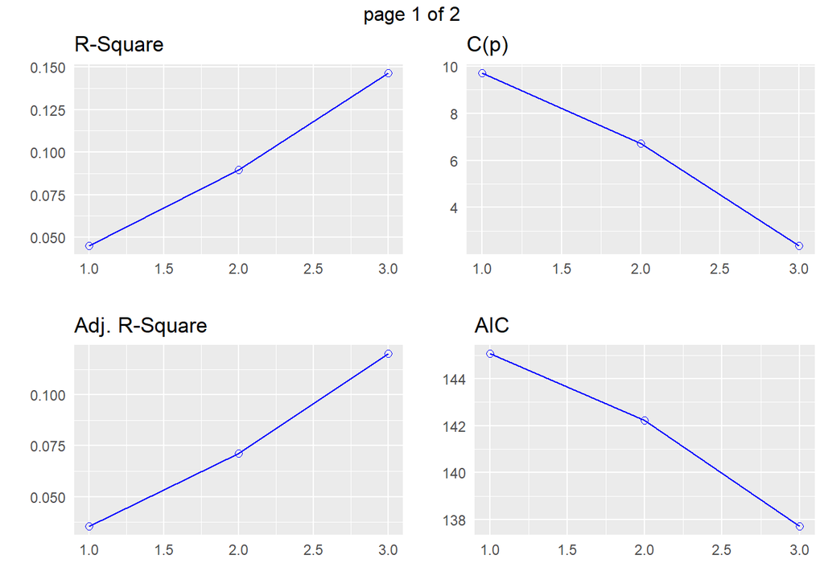

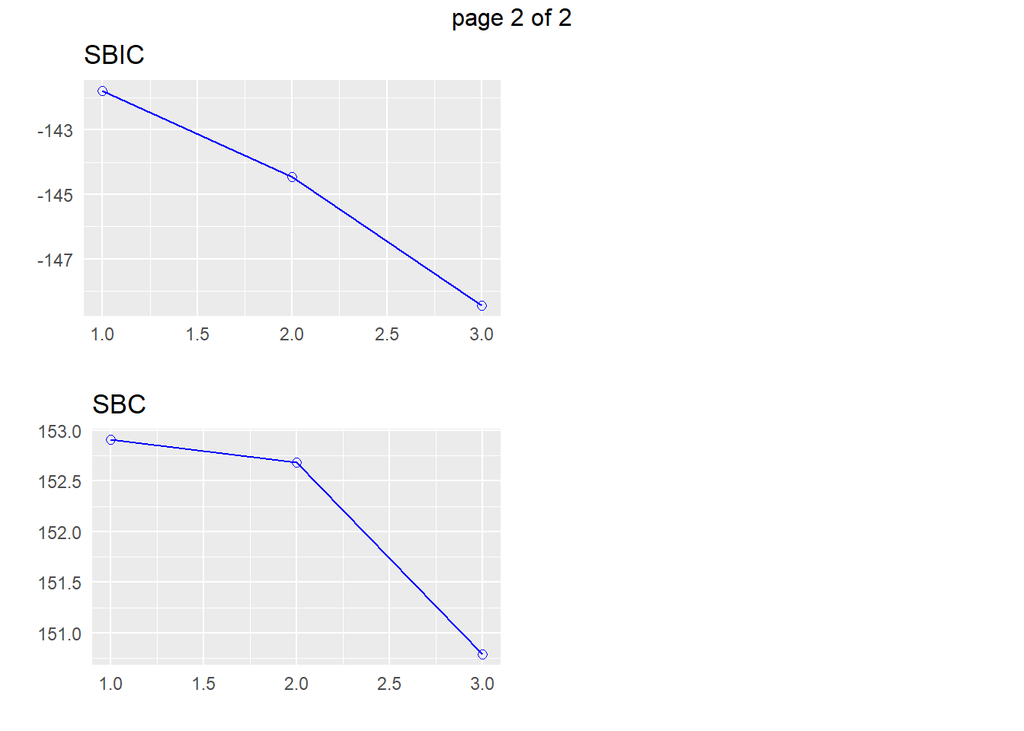

```r
plot(k)
```

독립변수의 개수별로 가장 적합한 모델을 나타낸다

adj-r-square와 cp와 aic를 고려 하였을때 4번 모델이 가장 좋아 보임임

```r
k <- ols_step_best_subset(model)
k
```

```
##                              Best Subsets Regression
## ----------------------------------------------------------------------------------
## Model Index    Predictors
## ----------------------------------------------------------------------------------
##      1         eye
##      2         hdlngth totlngth
##      3         hdlngth totlngth eye
##      4         hdlngth totlngth eye chest
##      5         hdlngth skullw totlngth eye chest
##      6         hdlngth totlngth taill eye chest belly
##      7         hdlngth skullw totlngth taill eye chest belly
##      8         age hdlngth skullw totlngth taill eye chest belly
##      9         age hdlngth skullw totlngth taill footlgth eye chest belly
##     10         age hdlngth skullw totlngth taill footlgth earconch eye chest belly
## ----------------------------------------------------------------------------------
##
##                                                     Subsets Regression Summary
## ----------------------------------------------------------------------------------------------------------------------------------
##                        Adj.        Pred
## Model    R-Square    R-Square    R-Square     C(p)        AIC         SBIC         SBC        MSEP       FPE       HSP       APC
## ----------------------------------------------------------------------------------------------------------------------------------
##   1        0.0450      0.0353      0.0075     9.7112    145.0591    -141.7863    152.9045    23.9046    0.2414    0.0024    0.9936
##   2        0.1119      0.0937      0.0569     4.2368    139.7248    -146.7948    150.1853    22.4594    0.2290    0.0023    0.9425
##   3        0.1465      0.1201      0.0739     2.3697    137.7103    -148.4500    150.7859    21.8091    0.2244    0.0022    0.9239
##   4        0.1698      0.1352      0.0792     1.7679    136.9166    -148.8374    152.6073    21.4374    0.2227    0.0022    0.9167
##   5        0.1771      0.1338       0.066     2.9484    138.0204    -147.4432    156.3263    21.4741    0.2251    0.0023    0.9268
##   6        0.1842      0.1322      0.0567     4.1505    139.1401    -145.9961    160.0610    21.5166    0.2277    0.0023    0.9373
##   7        0.1895      0.1285        0.04     5.5571    140.4805    -144.3266    164.0166    21.6089    0.2307    0.0023    0.9499
##   8        0.1941      0.1241       0.024     7.0441    141.9066    -142.5584    168.0578    21.7226    0.2341    0.0024    0.9635
##   9        0.1943      0.1146      0.0014     9.0275    143.8881    -140.3296    172.6544    21.9599    0.2387    0.0024    0.9828
##  10        0.1945      0.1050     -0.0228    11.0000    145.8572    -138.1094    177.2386    22.1999    0.2435    0.0025    1.0024
## ----------------------------------------------------------------------------------------------------------------------------------
## AIC: Akaike Information Criteria
##  SBIC: Sawa's Bayesian Information Criteria
##  SBC: Schwarz Bayesian Criteria
##  MSEP: Estimated error of prediction, assuming multivariate normality
##  FPE: Final Prediction Error
##  HSP: Hocking's Sp
##  APC: Amemiya Prediction Criteria
```

E:

설명력과은 무관하며 비례정도를 의미함